# Assignment 1

Kanchan Upadhyay

Assigned Oct 24; Due Nov 1 2017

## Problem 1 (1 pt)

1. Suppose you were going to survey people to better understand individual’s habits for commuting to school or work. Specify at least 5 ratio variables, 5 nominal variables, and 3 ordinal variables that you would include in your survey and indicate what R data types you would map to these variables.  
   To better understand individual’s habit for commuting to school or work, following variables can be used:  
   *1. Nominal Variables*
   - *Mode of Transport used(mode_transport); R data type used - Character*
   - *Vehicle Ownership(own_vehicle); R data type used- Factor with 2 levels: “Yes” & “No”*
   - *Gender(gender); R data type used- Factor with 2 levels: “Male” & “Female”*
   - *Locality(locality); R data type used- Factor with 3 levels: “Rural”, “Urban”, “Metropolitan”*
   - *Topography (topo); R data type used - Factor with 2 levels: “Plain”, “Hilly”*  
     *2. Ratio Variables*
   - *Commuting distance (commu_dist); R data type used - Numeric*
   - *Commuting duration (commu_time);R data type used - Numeric*
   - *Age(age);R data type used - Integer*
   - *Income(income);R data type used - Integer*
   - *Average Annual temperature in C(annual_temp); R data type used - Numeric*  
     *3. Ordinal Variables*
   - *Socioeconomic Status(socio_status); R data type used- factor with 3 levels: low, medium, high*
   - *Traffic condition (traffic_con);R data type used- factor with 3 levels: light, medium, heavy*
   - *Access to public transport (acc_trans); R data type used- factor with 3 levels: low,medium, high)*

## Problem 2 (2 points)

1. Assume your are preparing an inventory of computers used in class. You take a sample of 5 computers. Create 4 vectors that contain the computer make, hard drive space, operating system (either osx or windows only), age, and screen size. Show that the are the appropriate class (or type), such factor, numeric, etc. You can make up the content of the information.

```r
s.no.<-c(1,2,3,4,5)
computer_make<-c("Dell","Lenevo","Apple","Dell","HP")
hard_drive_space<-c(500,1000,250,200,500)
operating_system<-factor(c("Windows","Windows","OSx","Windows","Windows"))
age<-c(5,2,1,3,4)
screen_size<-c(14,15.6,20,24,32)
```

2. Assemble these vectors into a data frame called “class.computers” and print the class.computers to the console.

```r
require(tibble)
class.computers<-data.frame(s.no.,computer_make,hard_drive_space,operating_system,age,screen_size)
class.computers<-as.tibble(class.computers)
class.computers
```

```
## # A tibble: 5 x 6
##   s.no. computer_make hard_drive_space operating_system   age screen_size
##   <dbl>        <fctr>            <dbl>           <fctr> <dbl>       <dbl>
## 1     1          Dell              500          Windows     5        14.0
## 2     2        Lenevo             1000          Windows     2        15.6
## 3     3         Apple              250              OSx     1        20.0
## 4     4          Dell              200          Windows     3        24.0
## 5     5            HP              500          Windows     4        32.0
```

3. Use indexing to separately print the age field then all values of the third row.

```r
class.computers$age
```

```
## [1] 5 2 1 3 4
```

```r
class.computers[3,]
```

```
## # A tibble: 1 x 6
##   s.no. computer_make hard_drive_space operating_system   age screen_size
##   <dbl>        <fctr>            <dbl>           <fctr> <dbl>       <dbl>
## 1     3         Apple              250              OSx     1          20
```

## Problem 3 (1.5 point)

Replace “3”, “50”, “30”, and “5” with in-line code that assigns 3, 50, and 30 to a variable and uses those variables to calculate the expenditure on gasoline of 5. The result in your markdown file should be the same as the sentence below. All of your variable assignments must occur in-line with the sentence. If the price of gasoline is 3 dollars per gallon and I drive 50 miles in a car with a fuel economy of 30 miles per gallons, I will pay 5 dollars for gasoline. What would happen if, instead of writing the sentence as above, you tried to write the sentence as follows.  
I will pay 5 dollars for gasoline if the price of gasoline is 3 dollars per gallon and I drive 50 miles in a car with a fuel economy of 30 miles per gallons.

**Solution:**

If the price of gasoline is 3 dollars per gallon and I drive 50 miles in a car with a fuel economy of 30 miles per gallon, I will pay 5 dollars for gasoline.

If we have tried to write this sentence- “I will pay 5 dollars for gasoline if the price of gasoline is 3 dollars per gallon and I drive 50 miles in a car with a fuel economy of 30 miles per gallons.”, there would have been an error as the expenditure on gasoline can not be calculated before the other variables on which it is based are defined.

## Problem 4 (3.5 points)

### Get the data

I have set up an amazon website to store data so that you can use the “read.csv” function inside of your markdowns. For assignment 1, I have included the code to download the data below. However, you will be expected to create this code in the future.

```r
birthwt <- read.csv("https://s3.amazonaws.com/aws-website-programminginrforanalytics-tbal0/data/birthwt.csv", header = TRUE)
```

**Don’t change any of the data! Some of these data are problematic by design!**

### Install and load the packages

Install the package ggplot2. You can do this by either selecting “Install” from the “Package” pane, then typing ggplot2. You could also install it by running “install.pacakges(”ggplot2“) the console. Just don’t include the call to”install.packages" in your markdown for reasons we discussed in class.

Load ggplot2 with the function require() or by clicking on the box next to their names in the “packages” pane.

```r
require(ggplot2)
```

### Complete the assignment

Which of the fields in birthwt are assigned the wrong type (e.g., numeric, factor, integer)?

```r
str(birthwt) # Used structure function to look at the fields of the dataset and their type
```

```
## 'data.frame':    189 obs. of  14 variables:
##  $ low          : int  0 0 0 0 0 0 0 0 0 0 ...
##  $ age          : int  19 33 20 21 18 21 22 17 29 26 ...
##  $ lwt          : int  182 155 105 108 107 124 118 103 123 113 ...
##  $ race         : Factor w/ 3 levels "black","other",..: 1 2 3 3 3 2 3 2 3 3 ...
##  $ smoke        : int  0 0 1 1 1 0 0 0 1 1 ...
##  $ ptl          : int  0 0 0 0 0 0 0 0 0 0 ...
##  $ ht           : int  0 0 0 0 0 0 0 0 0 0 ...
##  $ ui           : int  1 0 0 1 1 0 0 0 0 0 ...
##  $ ftv          : int  0 3 1 2 0 0 1 1 1 0 ...
##  $ bwt          : int  2523 2551 2557 2594 2600 2622 2637 2637 2663 2665 ...
##  $ mother.other : int  0 1 0 0 0 1 0 1 0 0 ...
##  $ mother.white : int  0 0 1 1 1 0 1 0 1 1 ...
##  $ mother.black : int  1 0 0 0 0 0 0 0 0 0 ...
##  $ mother.smokes: Factor w/ 2 levels "no","yes": 1 1 2 2 2 1 1 1 2 2 ...
```

*Following fields have been assigned the wrong type:*

- low: It is defined as an integer but instead is should be a factor with 2 levels: “no”, “yes”:0 1 * smoke: It is defined as integer but instead is should be a factor with 2 levels: “no”, “yes”:0 1
- ht: It is defined as an integer but instead is should be a factor with 2 levels: “no”, “yes”:0 1
- ui: It is defined as an integer but instead is should be a factor with 2 levels: “no”, “yes”:0 1
- $mother.other: It is defined as an integer but instead is should be a factor with 2 levels: “no”, “yes”:0 1
- $mother.white: It is defined as an integer but instead is should be a factor with 2 levels: “no”, “yes”:0 1
- $mother.black: It is defined as an integer but instead is should be a factor with 2 levels: “no”, “yes”:0 1

Let’s explore what might influence birth weight by developing and viewing a series of plots. Prepare a scatter plot (type geom_point) that shows birth weight on the y-axis and age on the x-axis. Do you see any trends in this scatterplot?

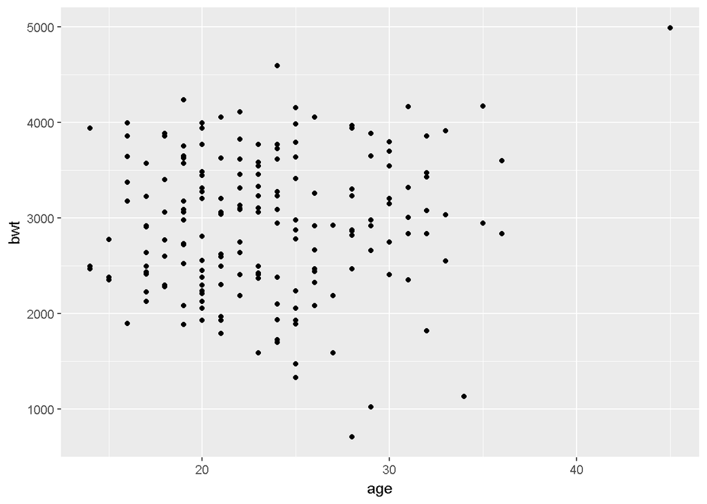

```r
ggplot(data=birthwt)+geom_point(mapping = aes(x=age,y=bwt))
```

*Any clear trends in variation of birthweight with mother’s age are not observable from this graph.*

Now color code the above scatter plot by the field “mother.black.” What is wrong with the legend scale and why is it happening?

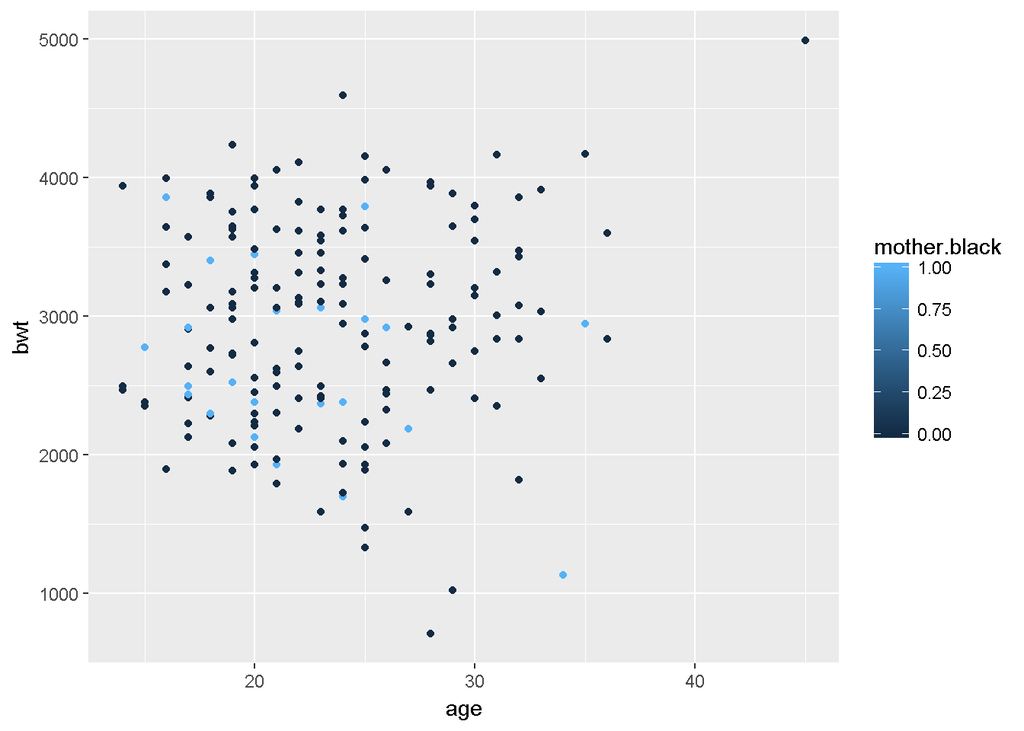

```r
ggplot(data=birthwt)+geom_point(mapping = aes(x=age,y=bwt,colour= mother.black))
```

*Error in the Legend scale: The colour coding for mother.black is continuous. This is happening because mother.black is defined as an integer instead of factor with 2 levels:“no”,“yes”. To obtain distinct color for this variable we have to define mother.black as factor variable.*

Now color code the above scatter plot by race and prepare a boxplot showing how birthwt varies by race. Did the boxplot identifier any outliers? For which race is the median birth weight lowest? For which race is the birth weight most variable? Of the two different graphs visualizing variation in birth weight by the mothers race, which do you prefer and why?

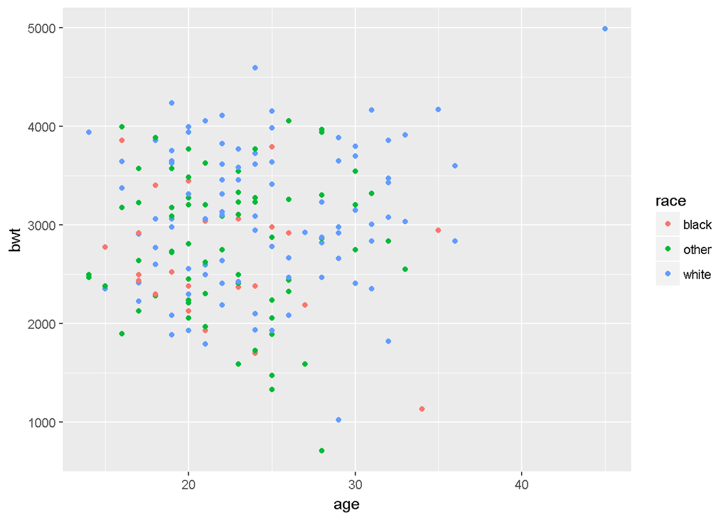

```r
ggplot(data=birthwt)+geom_point(mapping = aes(x=age,y=bwt,colour= race))
```

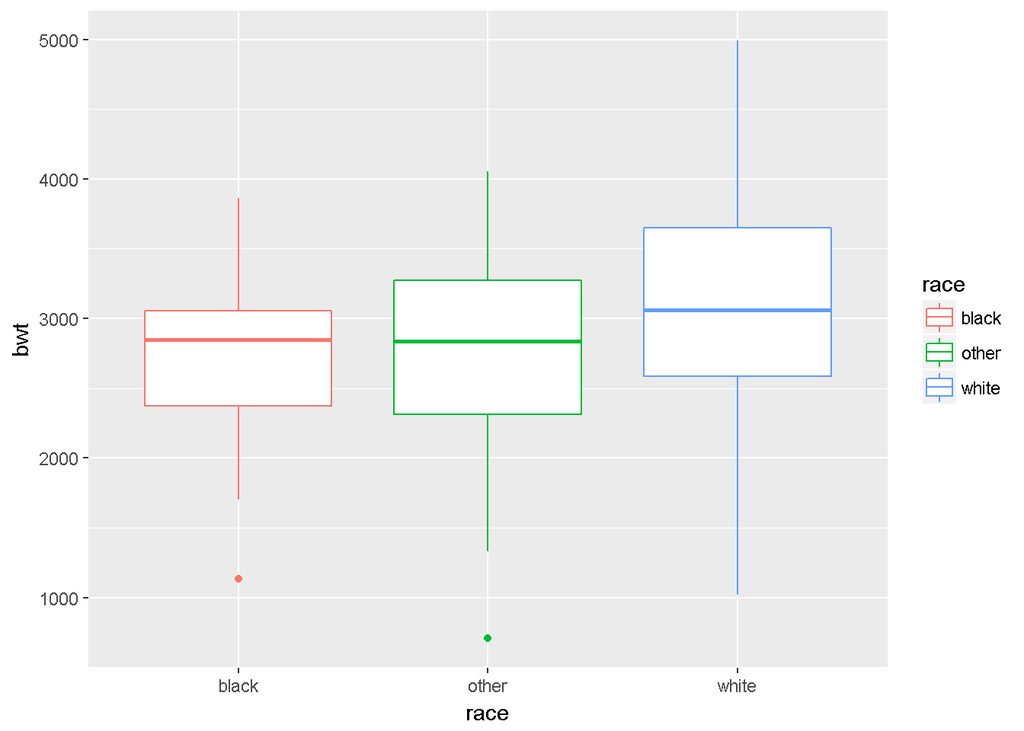

```r
ggplot(data=birthwt,aes(x=race,y=bwt,colour=race))+geom_boxplot()
```

*Yes, the box plot identifies outliers for “Black” and “Other” race*  
*Median birth weight is lowest for “Black” and “Other” race*  
*Birth weight is most variable for “White” race*

*I will prefer the boxplot as it gives additional information like quartiles, median value and variations in the data.*

Now assign to a variable (e.g., birthwt.plot) a ggplot object that takes only one argument: data = birth weight. Add to this object geom_point and geom_smooth graphs that shows age on the x-axis, birth weight on the y axis, and color codes the results by the variable mother.smokes. Make the “method” argument to geom_smooth “lm,” which stands for linear model. Done properly, your plot should include separate linear models for mothers who do and do not smoke.

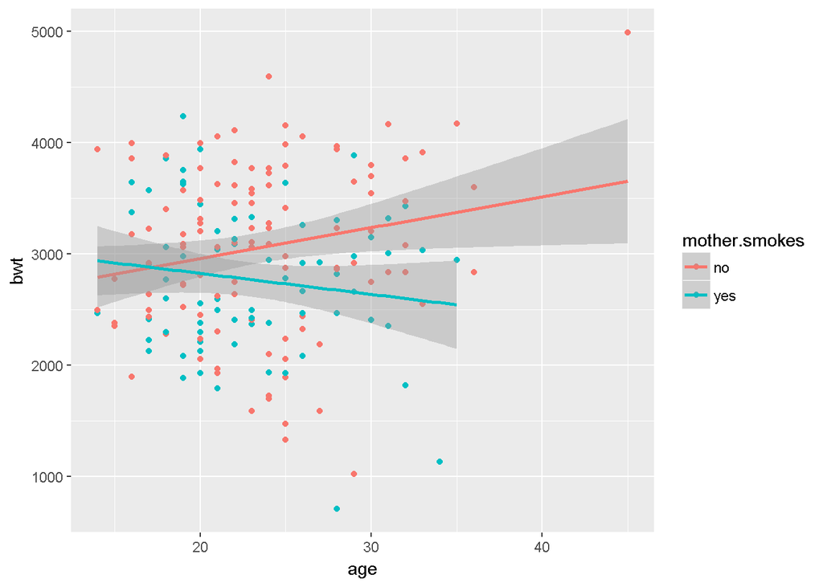

```r
birthwt.plot<-ggplot(data=birthwt)+geom_point(mapping=aes(x=age,y=bwt,colour= mother.smokes))+geom_smooth(mapping=aes(x=age,y=bwt, colour=mother.smokes),method = "lm")
birthwt.plot
```

Change the axis labels to read “mother’s age in years” and “newborn birth weight in grams.”

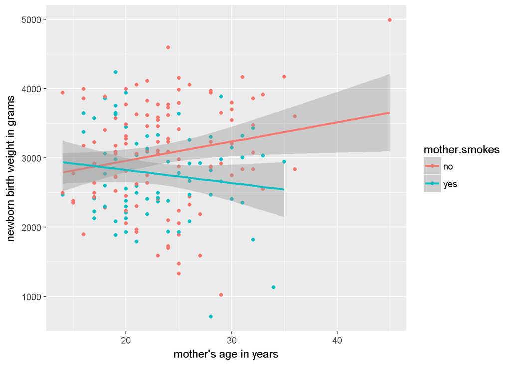

```r
birthwt.plot<-ggplot(data=birthwt)+geom_point(mapping=aes(x=age,y=bwt,colour= mother.smokes))+geom_smooth(mapping=aes(x=age,y=bwt, colour=mother.smokes),method = "lm") +xlab("mother's age in years")+ ylab("newborn birth weight in grams")
birthwt.plot
```

What do the results say about the effect of smoking on birthweight?

*For mother’s who smoke, the birthweight of the newborn decreases with increase in their age. While for mother’s who don’t smoke, the birthweight of newborn increases with increase in mother’s age. Also, for most of the mother’s age range, birthweight of newborn is more if the mother does not smokes.*